# Bayesian Modelling

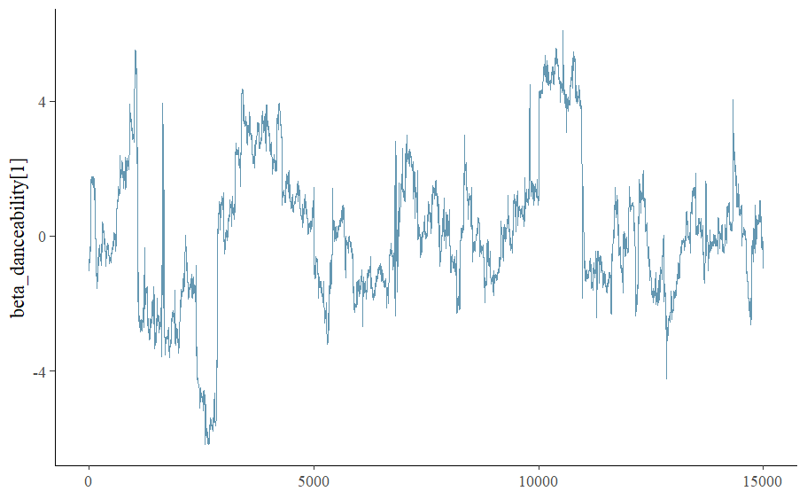

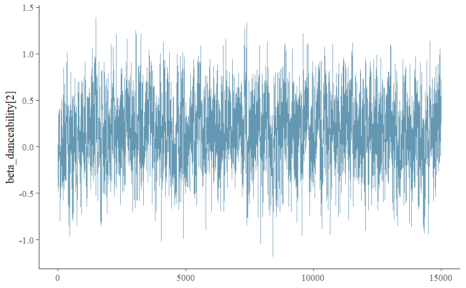

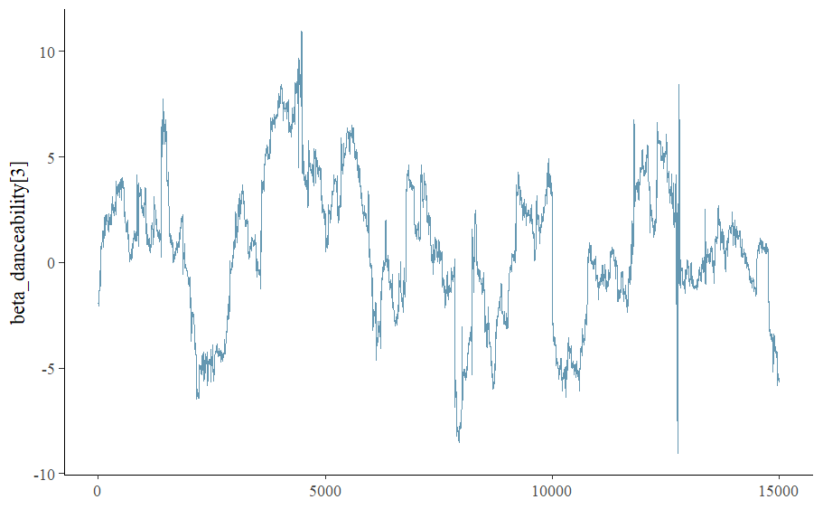

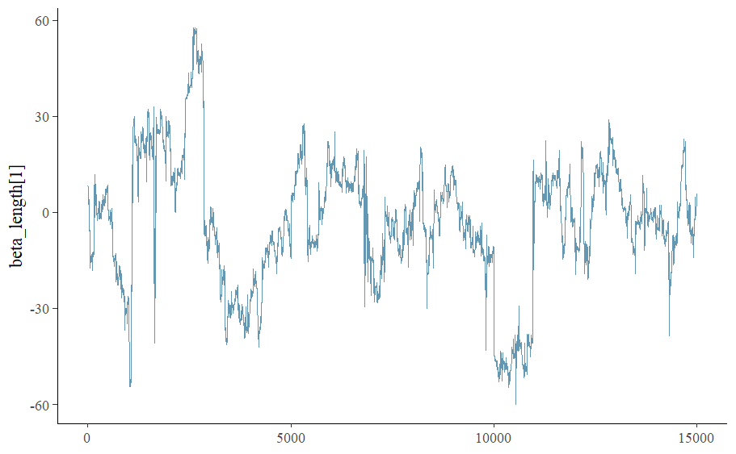

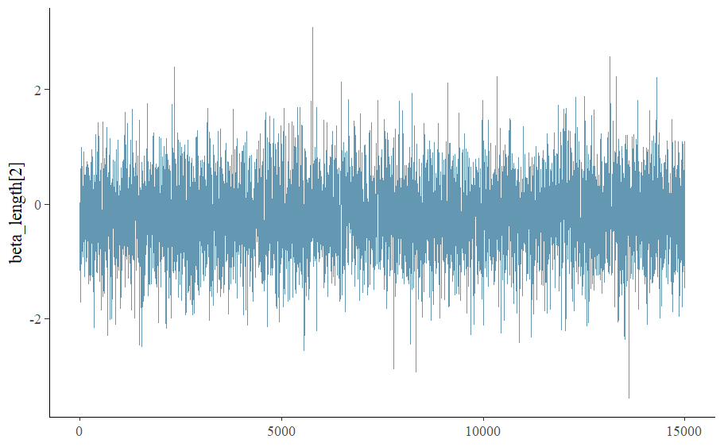

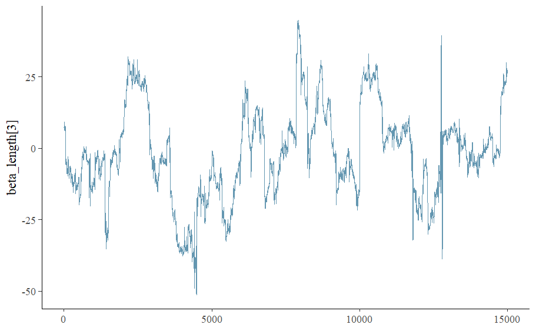

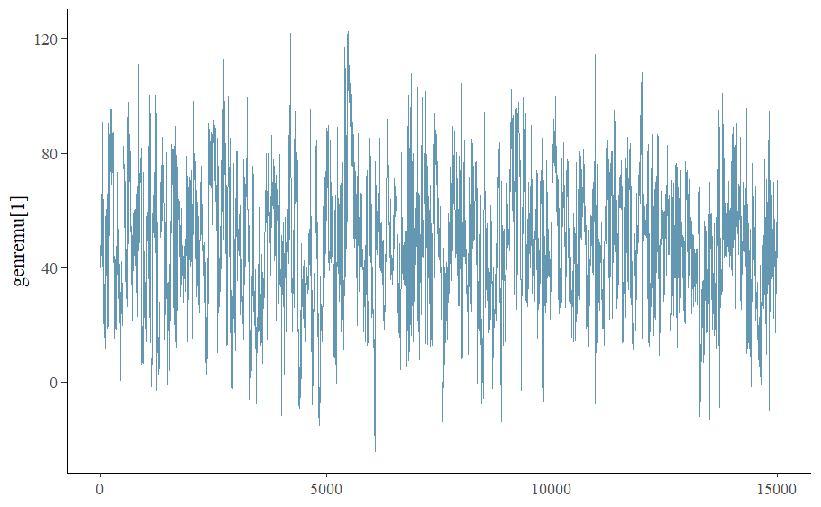

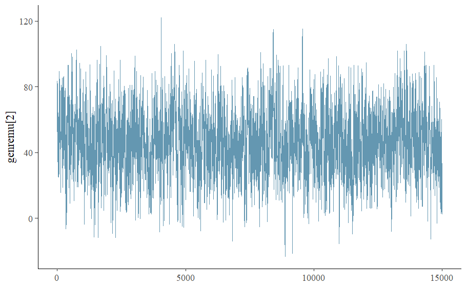

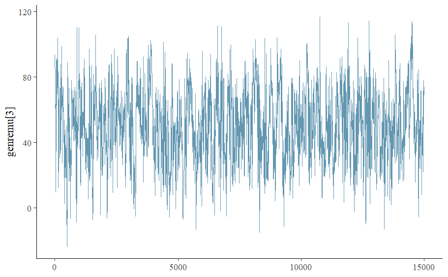

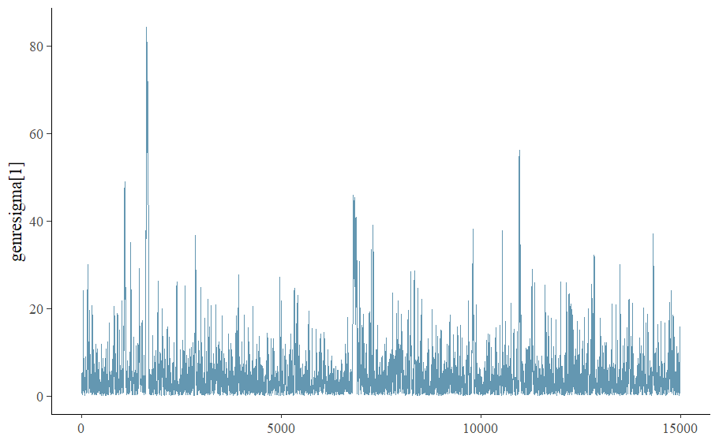

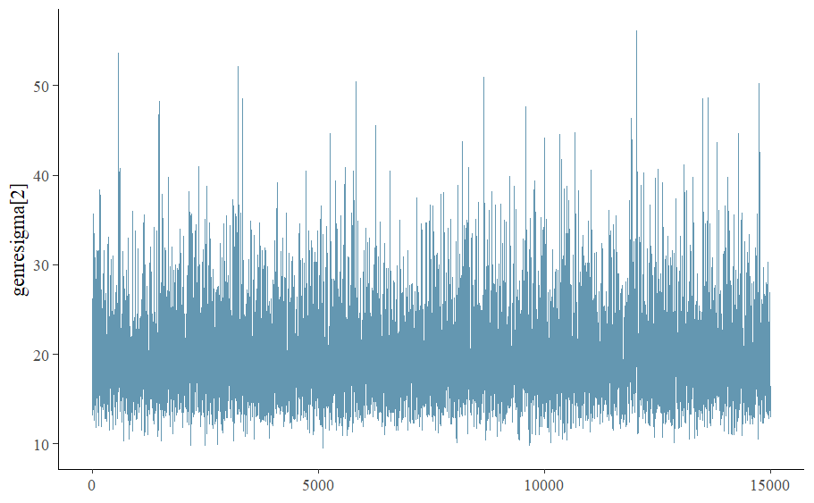

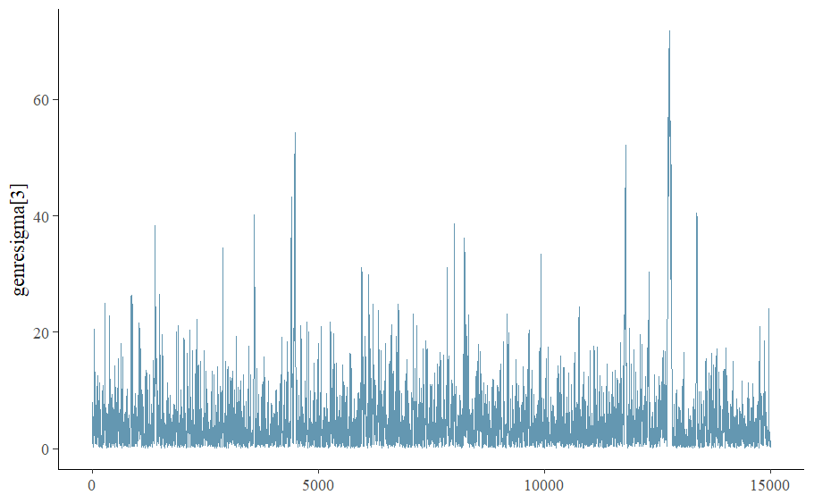

```r
# Prepare data to plot
fum_samples_df <- as.data.frame(as.matrix(fum_samples))

# Select the first 3 genres for simplicity
selected_genres <- 1:3

# Get column names for the selected genres
danceability_cols <- paste0("beta_danceability[", selected_genres, "]")
length_cols <- paste0("beta_length[", selected_genres, "]")
genremu_cols <- paste0("genremu[", selected_genres, "]")
genresigma_cols <- paste0("genresigma[", selected_genres, "]")

# Combine all selected columns into a single list
selected_cols <- c(danceability_cols, length_cols, genremu_cols, genresigma_cols)

# Subset the dataframe to only include these columns
selected_df <- fum_samples_df[, selected_cols]

# Create traceplots for each selected column
for (col in colnames(selected_df)) {
  trace <- mcmc_trace(as.matrix(fum_samples_df[col]), pars = col)
  print(trace)
}
```

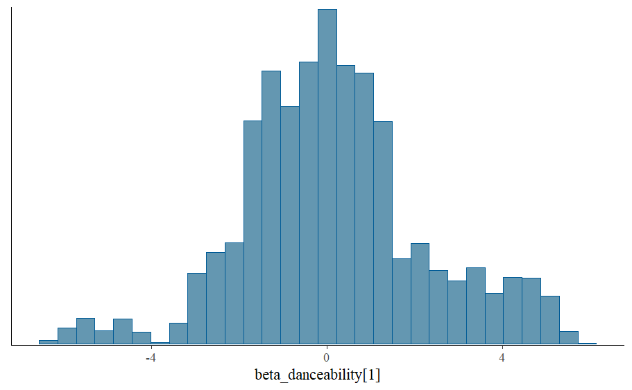

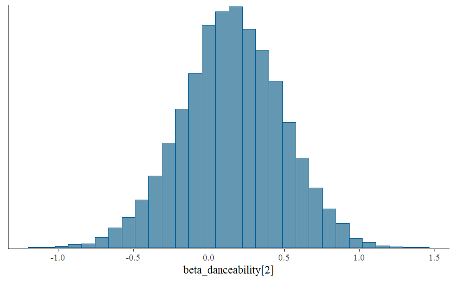

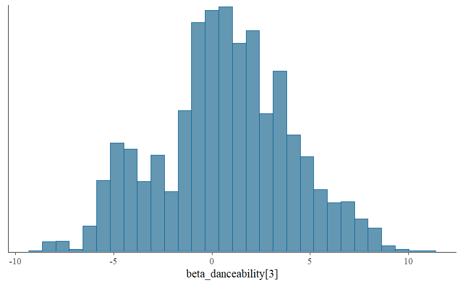

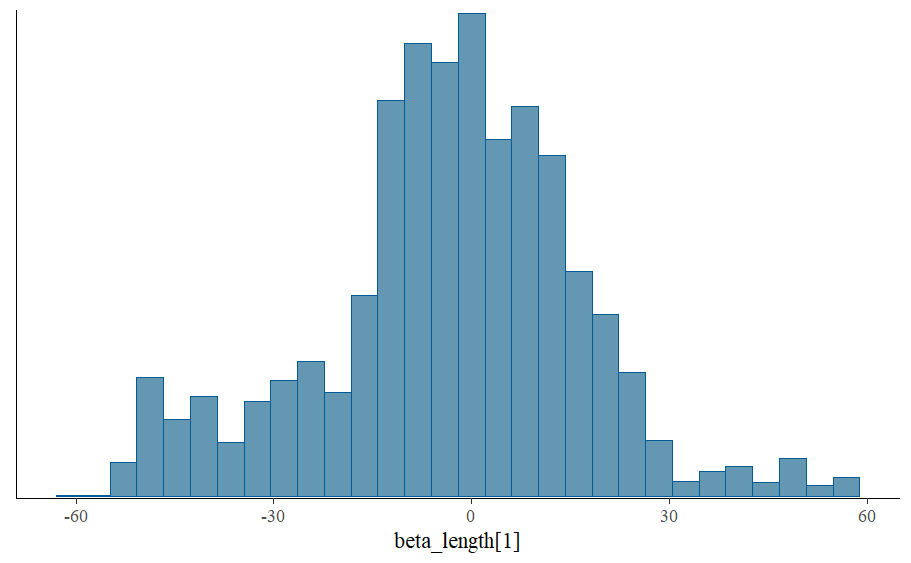

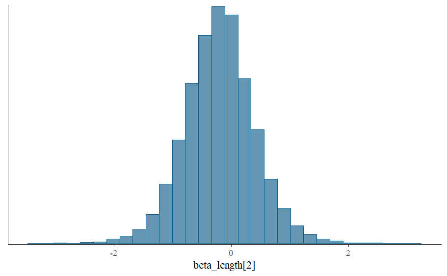

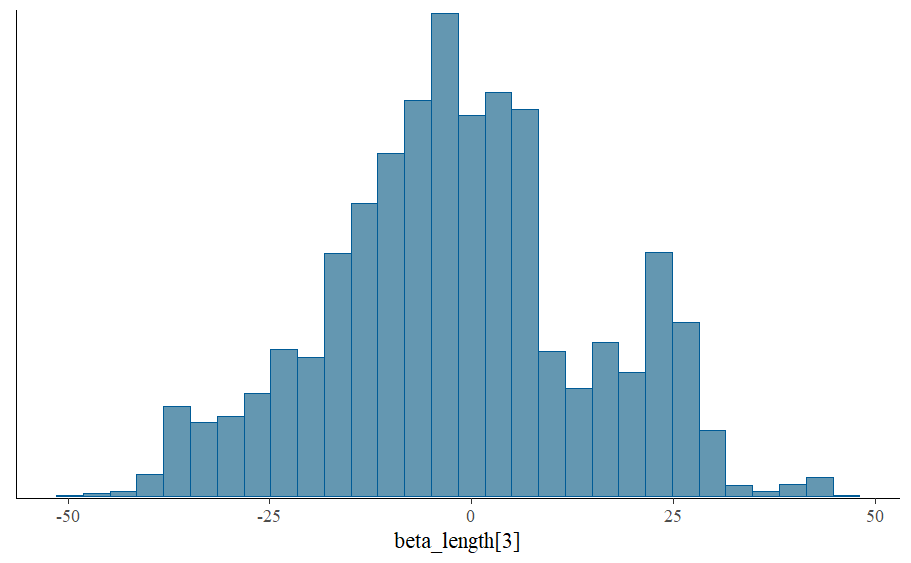

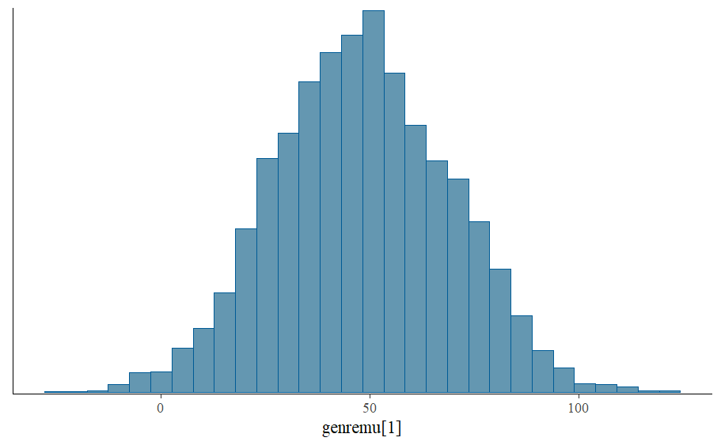

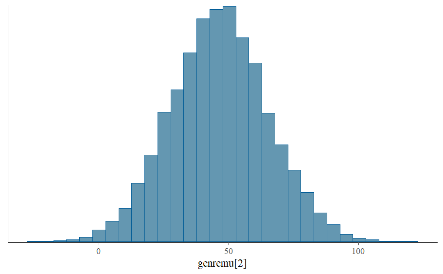

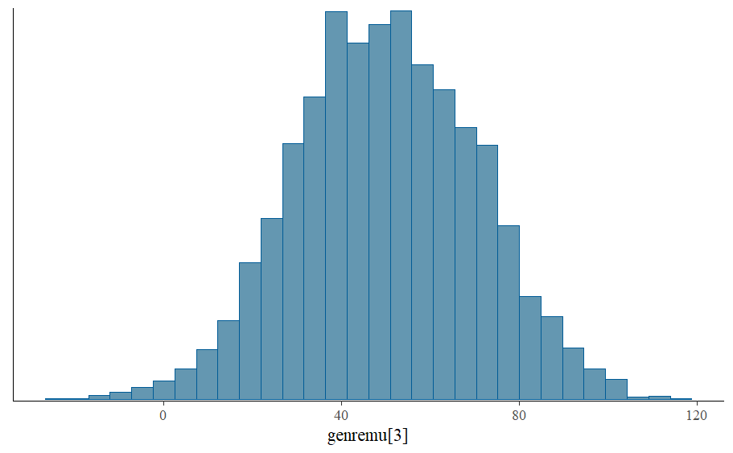

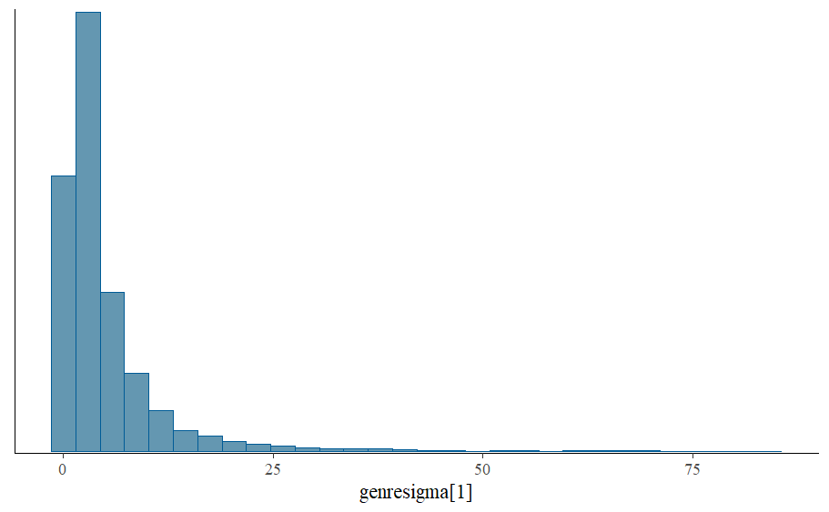

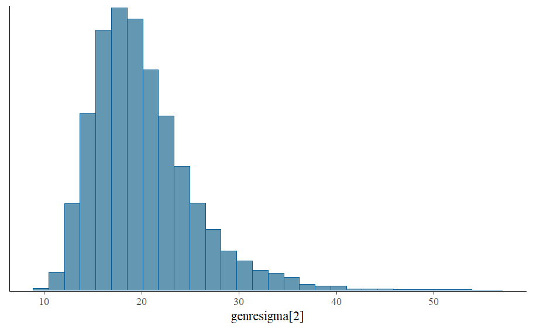

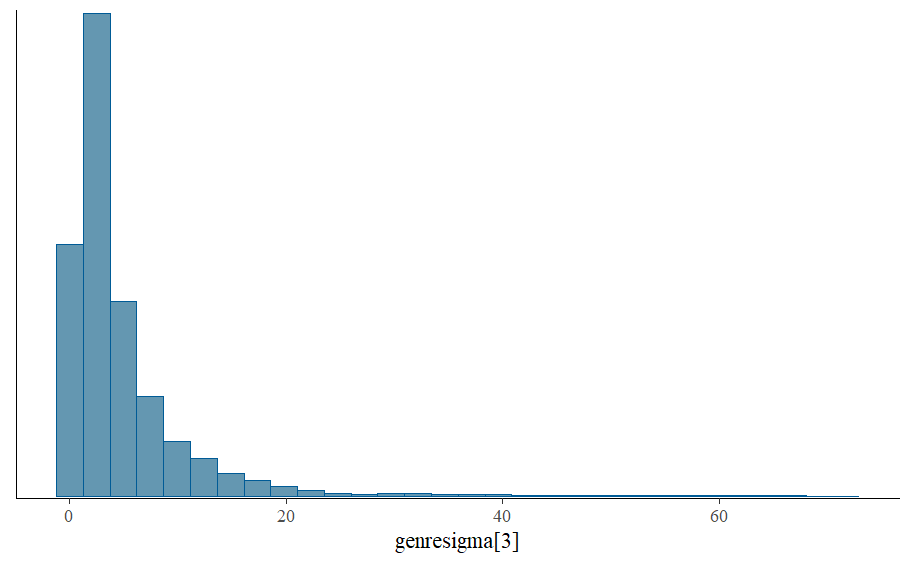

```r
# Create histograms for each selected column
for (col in colnames(selected_df)) {
  hist <- mcmc_hist(as.matrix(fum_samples_df[col]), pars = col)
  print(hist)
}
```

As we can see in these plots, the parameters converge differently for different genres and end up being distributed very differently from each other. Some genres behave better than the others, and we can also expect to obtain very different point estimates for each of them. It is important to notice that sometimes tihs might be due to some genres being more common than others, causing some of them to be underrepresented in the sample.

### Bayesian Hierarchical Model

```r
# Parameters to monitor
parameters <- c("sigma", "genremean", "genresigma", "tau", "genretau", "mu_beta_danceability", "mu_beta_length")

# Run Bayesian Hierarchical Model
bhm_model <- jags.model(textConnection(bhm_string), data = jags_data, n.chains = 3, n.adapt = 1000)
```

[output not shown]

```r
update(bhm_model, n.iter = 1000) # Burn-in
```

[output not shown]

```r
bhm_samples <- coda.samples(bhm_model, variable.names = parameters, n.iter = 5000)
```

[output not shown]

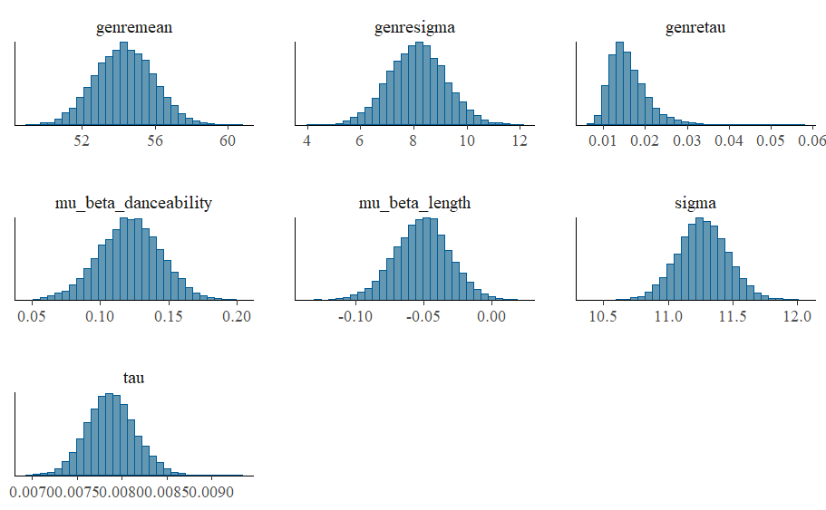

```r
# Prepare data to plot
bhm_samples_df <- as.matrix(bhm_samples)

# Plot the MCMC processes for each of our estimators
mcmc_hist(bhm_samples_df)
```

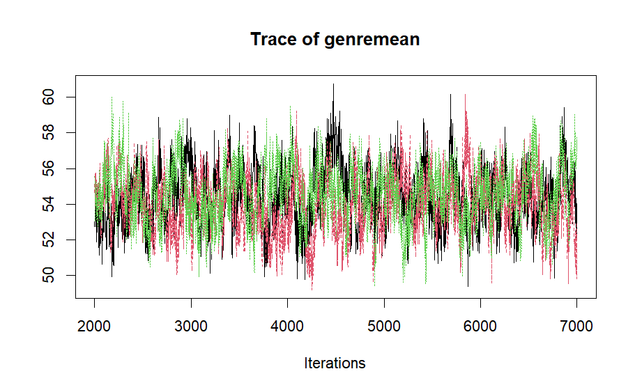

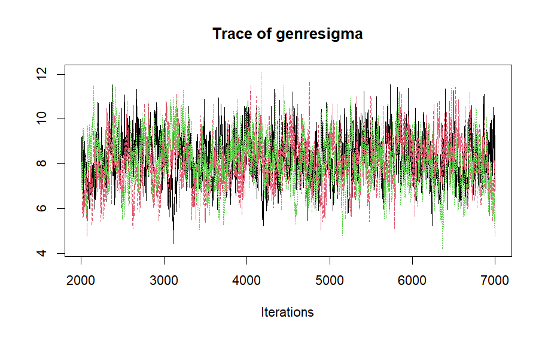

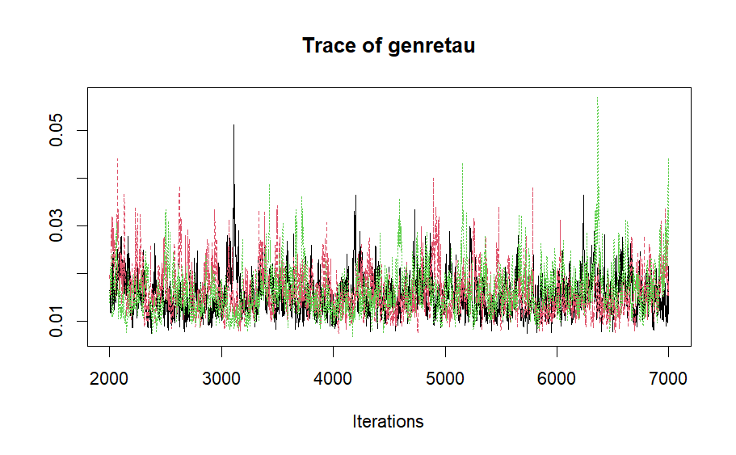

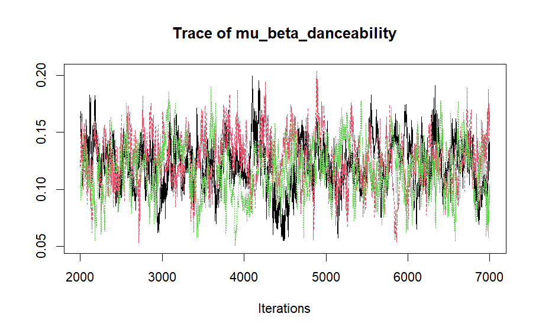

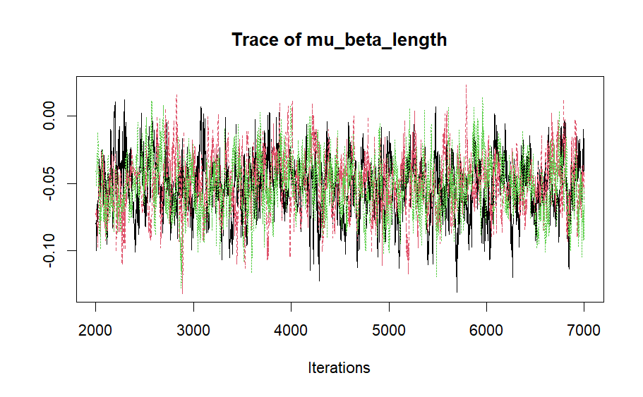

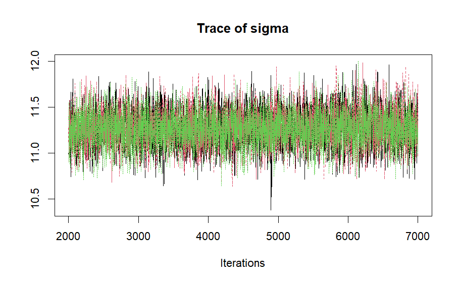

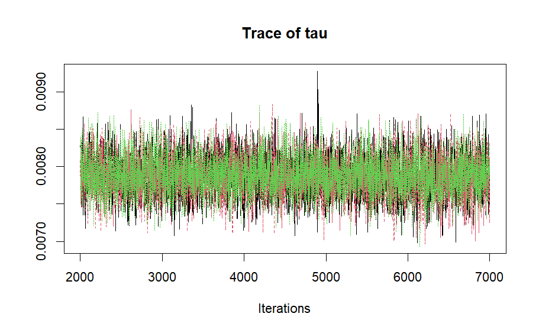

```r
traceplot(bhm_samples)
```

In the histograms we can observe very nicely distributed parameter values centered around similar values as in the fully pooled model, but with generally a lower range of uncertainty (Credible intervals). For the traceplot we can also observe convergence around that range of values although some of the MCMC processes wiggle ocassionally slightly.

## Model comparison

To evaluate the fit of our models, we will use the Deviance Information Criterion (DIC), since the WAIC and LOO-CV are more computationally expensive. This indicator Uses the posterior mean point estimate to evaluate the log-likelihood.

$$\hat{elpd}_{\text{DIC}} = \log \left[
p(\vec{x} \mid \hat{\theta}_{\text{Bayes}}) \right] -
k_{\text{DIC}}$$

with the bias correction term

$$k_{\text{DIC}} = 2 \,
\text{var}_{\text{posterior}} \left( \log \left[ p(\vec{x} \mid \theta)
\right] \right)$$

```r
# Calculate DIC values
dic_fpm <- dic.samples(fpm_model, n.iter = 5000)
```

[output not shown]

```r
dic_fum <- dic.samples(fum_model, n.iter = 5000)
```

[output not shown]

```r
dic_bhm <- dic.samples(bhm_model, n.iter = 5000)
```

[output not shown]

```r
# Turn into an interpreteable df
dic_values <- data.frame(
  Model = c("Fully Pooled", "Fully Unpooled", "Hierarchical"),
  DIC = c(sum(dic_fpm$deviance), sum(dic_fum$deviance), sum(dic_bhm$deviance))
)

print(dic_values)
```

| Model | DIC |
| --- | --- |
| Fully Pooled | 15449.77 |
| Fully Unpooled | 14072.87 |
| Hierarchical | 14557.37 |

Our results show the lowest DIC for the fully unpooled model followed by the hierarchical model, and lastly, by the fully pooled one. This means that the fully unpooled model fits the data better than the others, which is due to its high complexity. However, we have to know that this model is difficult to generalize to other settings, so we need a more flexible model like the Hierarchical one.

The hierarchical model has a DIC which lies in between the other two, which is what we expected at the beginning since it also lies in-between both in terms of complexity. This model accounts for the hierarchical structure while taking into account the dependencies between groups, making it flexible and interpretable at the same time. Lastly, we have the fully pooled model, which explains the data in the least effective way, but gives the most simple and summarized estimates to interpret.

To interpret these results, it is important to remark two points: First, this is not a statistical significance test that allows us to contrast different models. And second, bayesian modelling is not about getting better predictions from our model, but to get our model closer to the complex and unpredictable reality.

In conclusion, depending on our research goals we can choose one of the different models proposed here. However, the model that is more flexible and easy to interpret, while not loosing to much of the nuances underlying the data is the hierarchical model.

## Future Studies

For future projects it would be interesting to take into account also artist specific features into a three level hierarchical model. In this analysis we haven’t considered a factor that might influence the popularity of a song in such a big way as the artist itself because it would make this project too complex for my time constraints and capabilities. This could be a very interesting extension of the current analysis, as it would allow us to understand how much of the popularity of a song is due to the artist’s prior popularity in its current career (for example) and how much is due to the song’s/genre’s features themselves and the popularity of the genre. Therefore, further research is required to approach the problematic of this topic.